# JUDGE channel — I. Descriptives & response processes

Implicit personality theory in 12 LLMs, read as a rating instrument

ecb

2026-07-23

## What this data is, and the stance I take on it

The **JUDGE** channel (rgb’s `tom_likely`) asks each model, for every ordered pair of 523 person-descriptive adjectives *(i, j)*, *“how strongly would a person described as **i** also be **j**?”* and reads the answer as an **expected rating on a 1–7 Likert scale** from the full log-prob distribution over the rating tokens (not the argmax). Each model therefore produces a `523 × 523` matrix **B** of conditional-endorsement ratings (row-conditioned, *not* symmetric, diagonal not collected), plus a matching matrix **Hent** of the Shannon entropy of each rating distribution — a per-judgment uncertainty.

rgb’s own analyses of this data (W15–W16) are **geometric and mechanistic**: the read/write dissociation, a Helmholtz–Hodge decomposition of the asymmetry, factor congruence to the human 525-PDA. This report series takes the **psychometric** view the geometry brackets: *if we treat these judgments as measurements, are they sound?* The unit I adopt (per ecb’s steer) is **models as raters** — **12 judges** rating the same 273,006 ordered pairs. (This reanalysis is built on rgb’s **full 7-category raw distributions**, `judge_dists_full`, complete for all 12 cohort models as of 2026-07-20. Earlier versions of these reports used a 12-model EV-only release; the raw distributions supersede it — see the caveat below.) Reliability, validity and response-process questions all follow from the models-as-raters frame.

This first report is the descriptive floor: **how does each rater use the scale?** Everything downstream (what to do about asymmetry; whether the raters agree; whether the structure is interpretable) is conditioned by the response processes documented here.

> **Data provenance, stated once — and it shapes the method here.** This reanalysis works from the **full 7-category rating distributions** `dists` (523×523×7 per model), from which I recompute `B` (the expected rating) and `Hent` (the entropy) in float64 so the two moments are internally consistent (the entropy envelope of §1B is respected by construction). These raw distributions **supersede** the earlier EV-only release, whose bf16 numerics had drifted (mean |ΔEV| 0.02–0.09, with bimodal cells’ EV flipping by up to ~4). Because §§1–5 are framed on the two moments (`B`, `Hent`) — the summary a rater’s *location* and *decisiveness* are captured by — I keep that framing throughout for continuity and because it is the right altitude for the response-style story; the **spread index** (§1B) places each judgment’s entropy between the minimum and maximum attainable at its mean, a mean-detrended proxy for how diffuse the underlying distribution is. But two moments cannot see *shape* (an EV of 4 from “all mass on 4” and from “half on 1, half on 7” are opposite response processes that round identically), and **now we can**: **§6 uses the full 523² raw distributions** to give the honest category usage, floor/ceiling, and a shape census — and it **corrects the earlier medoid-based verdict** that the two-moment proxy was faithful for 10/12 models. `Phi4`, `Aya` and `FalconMamba` are *not* summarized by EV alone; the earlier error was one of *metric* (reading faithfulness off strict bimodality) rather than the medoid sample, which in fact tracked off-mode mass reasonably well.

```r
summ <- read_csv_("model_summary.csv") %>% as_tibble() %>%
  mutate(display = factor(display, levels = disp_ord))
marg <- read_csv_("marginals.csv") %>% as_tibble()
dir_ev <- fread_gz("dir_ev.csv.gz")     # i,j, <12 models>  (273006 directional EVs)
dir_h  <- fread_gz("dir_hent.csv.gz")
# long form for distributional plots
ev_long <- melt(dir_ev, id.vars = c("i","j"), variable.name = "model", value.name = "ev")
ev_long[, display := factor(DISPLAY[as.character(model)], levels = disp_ord)]
ev_long[, family  := FAMILY[as.character(model)]]
h_long <- melt(dir_h, id.vars = c("i","j"), variable.name = "model", value.name = "hent")
```

## 1. Scale usage: some raters never leave the middle

The single most consequential descriptive fact is that the 12 models **do not use the 1–7 scale in remotely the same way.** The table sorts by mean rating (leniency); note especially the spread column (`ev_sd`) and the EV tail fractions (share of judgments with an expected rating in each band).

```r
tab <- summ %>% arrange(ev_mean) %>%
  transmute(Model = display, Family = family, `Params (B)` = params_b,
            `Mean` = round(ev_mean,2), `SD` = round(ev_sd,2),
            `Skew` = round(ev_skew,2), `Excess kurt.` = round(ev_kurtosis,2),
            `% ≤2` = round(100*frac_le2,1), `% 3–5` = round(100*frac_mid_3to5,1),
            `% ≥6` = round(100*frac_ge6,1))
knitr::kable(tab, caption = "Per-rater location, spread and tail usage of the 1–7 scale.")
```

Per-rater location, spread and tail usage of the 1–7 scale.

| Model | Family | Params (B) | Mean | SD | Skew | Excess kurt. | % ≤2 | % 3–5 | % ≥6 |
| --- | --- | --- | --- | --- | --- | --- | --- | --- | --- |
| Qwen2.5-7B | Qwen | 7.0 | 3.64 | 1.14 | 0.03 | 0.78 | 8.2 | 69.0 | 3.0 |
| Qwen2.5-3B | Qwen | 3.0 | 3.72 | 1.64 | -0.01 | -0.75 | 17.5 | 45.2 | 9.2 |
| Qwen2.5-32B | Qwen | 32.0 | 3.74 | 1.09 | -0.40 | 0.93 | 7.9 | 72.1 | 1.8 |
| FalconMamba-7B | Falcon | 7.0 | 3.87 | 0.75 | 0.15 | -0.60 | 0.1 | 80.3 | 0.1 |
| Gemma-4-31B | Gemma | 31.0 | 4.04 | 0.99 | -0.12 | 1.80 | 3.0 | 75.9 | 5.4 |
| Llama3.1-8B | Llama | 8.0 | 4.12 | 1.02 | -0.29 | -0.16 | 2.8 | 65.0 | 1.2 |
| Gemma3-4B | Gemma | 4.0 | 4.25 | 1.46 | 0.35 | -1.18 | 1.3 | 45.4 | 18.4 |
| Gemma3-12B | Gemma | 12.0 | 4.29 | 1.21 | -0.01 | -0.68 | 1.4 | 54.7 | 8.5 |
| Gemma3-27B | Gemma | 27.0 | 4.37 | 1.40 | -0.07 | -0.88 | 2.6 | 49.0 | 19.3 |
| Llama3.2-3B | Llama | 3.2 | 4.61 | 0.46 | -0.44 | 2.83 | 0.1 | 80.7 | 0.0 |
| Aya-expanse-8B | Aya | 8.0 | 4.65 | 1.95 | -0.54 | -0.90 | 14.7 | 29.6 | 33.5 |
| Phi4-mini-3.8B | Phi | 3.8 | 4.83 | 1.72 | -0.51 | -0.90 | 8.3 | 29.9 | 34.7 |

### 1A. The distribution of the expected rating

Rather than round `B` into pseudo-categories, plot its actual distribution per rater — the density of the expected-rating statistic itself. This shows leniency (location) and range restriction (spread) directly and honestly.

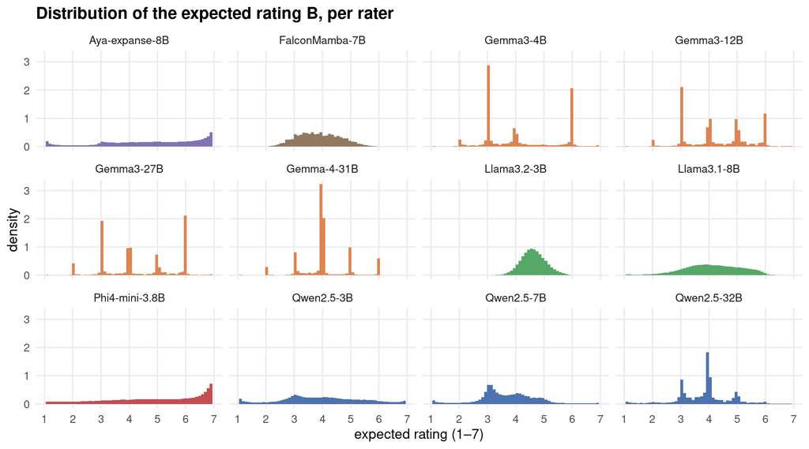

```r
ggplot(ev_long, aes(ev)) +
  geom_histogram(aes(y = after_stat(density), fill = family), bins = 60) +
  facet_wrap(~display, ncol = 4) +
  scale_fill_manual(values = FAM_PAL, guide = "none") +
  scale_x_continuous(breaks = 1:7, limits = c(1,7)) +
  labs(title = "Distribution of the expected rating B, per rater",
       x = "expected rating (1–7)", y = "density") +
  theme_judge()
```

Read as a **response-style census**:

- **Range-restricted / central responders.** `Llama3.2-3B`’s expected ratings collapse onto a narrow 4–5 band (SD = 0.46) — whatever the pair, the answer is “middling”. `FalconMamba-7B` is similarly compressed (SD = 0.75) but for a different reason: §3/§6 show it sits near the *uniform* entropy ceiling (broad distributions whose means land mid-scale), not a confident middle.
- **Full-range responders with ceiling/floor mass.** `Aya-expanse-8B` and `Phi4-mini` spread expected ratings across the whole scale with heavy mass toward the ceiling (SD ≈ 1.7–1.9) — §6 shows these are among the models whose raw distributions are genuinely diffuse (real mass at both ends), not just wide-ranging means.
- **Gemma family** is central-to-high and, on the raw data (§6), the most *concentrated* (`Gemma-4-31B` is the sharpest rater in the cohort).
- **Qwen family** sits modal around 3–4 (the most parsimonious raters, mean 3.6–3.7) with intermediate spread.

### 1B. Spread index: are the *underlying* distributions concentrated or diffuse?

The expected rating hides the shape of the distribution it came from. Since we also hold each judgment’s entropy, we can recover *how concentrated* the underlying rating distribution is, **detrended for its mean** — the raw entropy mechanically falls near the scale ends, so a bare entropy comparison confounds concentration with leniency. The **spread index** places each judgment’s entropy between the minimum and maximum entropy attainable at its mean (0 = as concentrated as any distribution with that mean can be; 1 = maximally diffuse). It is the closest honest proxy to the raw response shape.

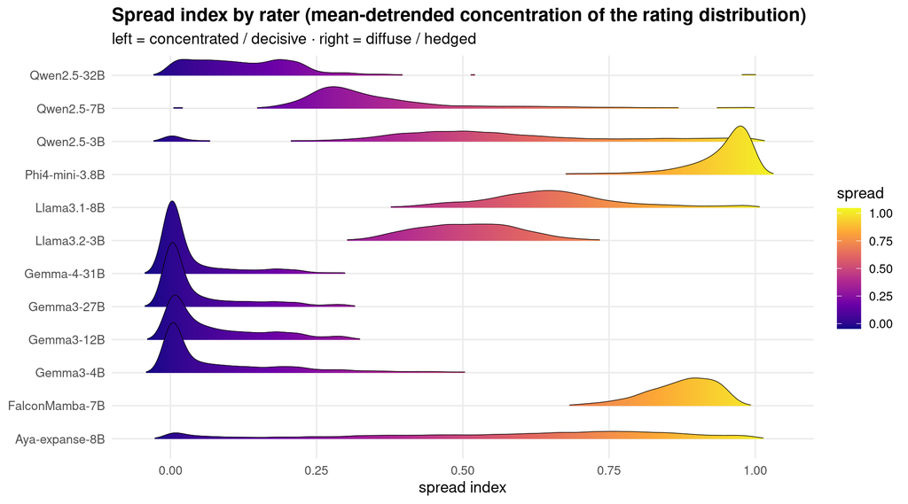

```r
ev_long[, spread := spread_index(ev, h_long$hent)]
sp_summ <- ev_long[, .(mean_spread = mean(spread, na.rm = TRUE)), by = display]
ggplot(ev_long[!is.na(spread)][sample(.N, 120000)], aes(spread, y = display, fill = after_stat(x))) +
  ggridges::geom_density_ridges_gradient(scale = 2.2, rel_min_height = 0.01, linewidth = 0.2) +
  scale_fill_viridis_c(name = "spread", option = "C") +
  labs(title = "Spread index by rater (mean-detrended concentration of the rating distribution)",
       subtitle = "left = concentrated / decisive · right = diffuse / hedged",
       x = "spread index", y = NULL) +
  theme_judge() + theme(legend.position = "right")
```

```r
knitr::kable(
  sp_summ %>% arrange(mean_spread) %>% transmute(Model = display, `Mean spread` = round(mean_spread,3)),
  caption = "Mean spread index per rater — a mean-independent response-style axis.")
```

Mean spread index per rater — a mean-independent response-style axis.

| Model | Mean spread |
| --- | --- |
| Gemma-4-31B | 0.045 |
| Gemma3-27B | 0.063 |
| Gemma3-12B | 0.085 |
| Gemma3-4B | 0.108 |
| Qwen2.5-32B | 0.167 |
| Qwen2.5-7B | 0.367 |
| Llama3.2-3B | 0.512 |
| Qwen2.5-3B | 0.532 |
| Aya-expanse-8B | 0.568 |
| Llama3.1-8B | 0.652 |
| FalconMamba-7B | 0.870 |
| Phi4-mini-3.8B | 0.935 |

This **re-sorts the cohort on a genuinely different axis than leniency or SD**: the Gemma family produces the most *concentrated* underlying distributions (mean spread 0.05–0.11, `Gemma-4-31B` the sharpest — it commits to sharp judgments) while `Phi4-mini` and `FalconMamba-7B` are the most *diffuse* (0.87–0.94 — their judgments are broad even where the expected rating is mid-scale). Note this is not the same as the SD of `B`: a rater can produce a wide range of expected ratings out of individually *diffuse* distributions (`Phi4`) or a narrow range out of *sharp* ones. Concentration and differentiation are distinct response-style dimensions — the point §4 formalizes.

This is exactly the heterogeneity that makes cross-model *magnitude* comparison unsafe (rgb’s calibration caveat) — but stated in response-style terms it is sharper: **these are different rating styles, not just different means.** Range restriction limits how much *differentiated information* a rater can carry (it caps the achievable between-pair variance) — though, importantly, Report III shows it does **not** make these raters disagree with the crowd: a flat rater is low-information, not noisy.

## 2. Location and spread are only loosely coupled

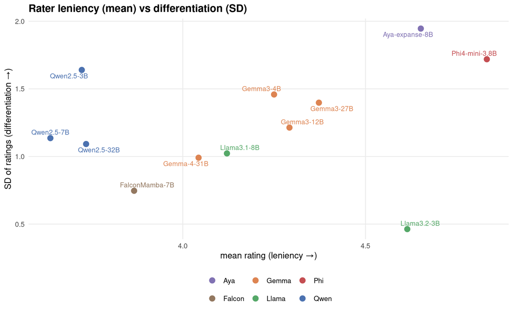

```r
ggplot(summ, aes(ev_mean, ev_sd, colour = family, label = display)) +
  geom_point(size = 3) +
  ggrepel::geom_text_repel(size = 3, max.overlaps = 20, seed = 1) +
  scale_colour_manual(values = FAM_PAL, name = NULL) +
  labs(title = "Rater leniency (mean) vs differentiation (SD)",
       x = "mean rating (leniency →)", y = "SD of ratings (differentiation →)") +
  theme_judge()
```

Leniency (mean 3.64 → 4.83) and differentiation (SD 0.46 → 1.95) vary independently: `Llama3.2-3B` is *lenient but flat* (high mean, tiny SD — it agrees warmly with almost everything), whereas `Aya` is *lenient and spread*. A high mean does not buy you usable variance. For the measurement, **differentiation (SD) is the resource** — a rater with SD 0.47 can encode at most a sliver of true between-pair signal.

## 3. Decisiveness: the entropy channel is a second, partly independent axis

Each judgment carries an entropy. Averaged per rater, this is a **decisiveness** index that is *not* the same thing as scale spread.

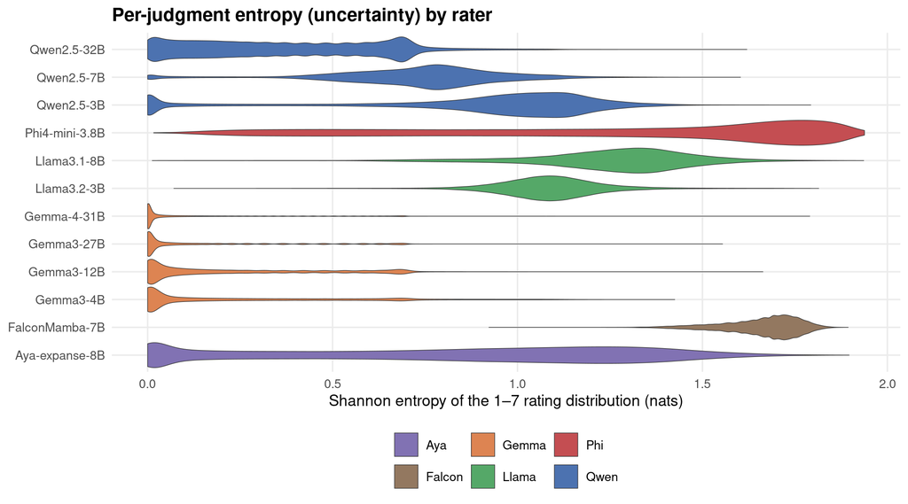

```r
ggplot(h_long, aes(x = factor(DISPLAY[as.character(model)], levels = disp_ord), y = hent,
                   fill = FAMILY[as.character(model)])) +
  geom_violin(scale = "width", linewidth = 0.2) +
  scale_fill_manual(values = FAM_PAL, name = NULL) +
  coord_flip() +
  labs(title = "Per-judgment entropy (uncertainty) by rater",
       x = NULL, y = "Shannon entropy of the 1–7 rating distribution (nats)") +
  theme_judge()
```

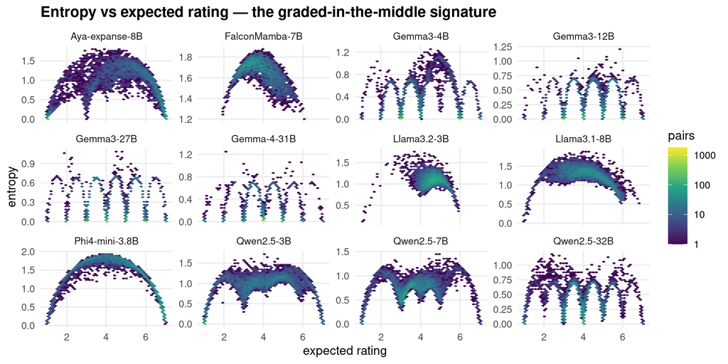

```r
# entropy as a function of the rating level: the response-process signature
set.seed(1)
samp <- ev_long[sample(.N, 60000)][, .(i,j,model,ev)]
samp <- merge(samp, h_long[, .(i,j,model,hent)], by = c("i","j","model"))
samp[, display := factor(DISPLAY[as.character(model)], levels = disp_ord)]
ggplot(samp, aes(ev, hent)) +
  geom_hex(bins = 40) + scale_fill_viridis_c(trans = "log10", name = "pairs") +
  facet_wrap(~display, ncol = 4, scales = "free_y") +
  labs(title = "Entropy vs expected rating — the graded-in-the-middle signature",
       x = "expected rating", y = "entropy") +
  theme_judge() + theme(legend.position = "right")
```

Two things:

1. **The inverted-U** (entropy peaks at mid-scale, collapses at the extremes) is present for the discriminating raters — a *sensible* response process: the model is certain when it judges a pair clearly (dis)similar and hedges in between.
2. **The non-responsive raters break it.** `FalconMamba-7B` sits at entropy ≈ 1.66 nats almost everywhere (near the `log(7)=1.95` uniform ceiling) — it is *maximally uncertain on nearly every pair*. `Llama3.2-3B` is similar in effect (mean ≈ 1.09 nats and essentially never decisive: only 0.002% of its judgments have entropy < 0.1, versus 49–67% for the Gemma family). Their narrow EV in §1 is now explained: they are not compressing a confident signal, they are **reporting near-flat distributions whose means happen to sit mid-scale.** (Note the discriminating raters `Phi4-mini` and `Llama3.1-8B` also carry high entropy, ≈ 1.26 nats, but *do* differentiate — a wide-then-hedged style, not non-response; §6 confirms `Phi4` carries real off-mode mass.)

## 4. A response-process typology: two kinds of “uncertain”

Crossing scale differentiation (SD of `B`) against concentration (mean spread index, §1B — the mean-detrended decisiveness) separates raters that look similar on either axis alone.

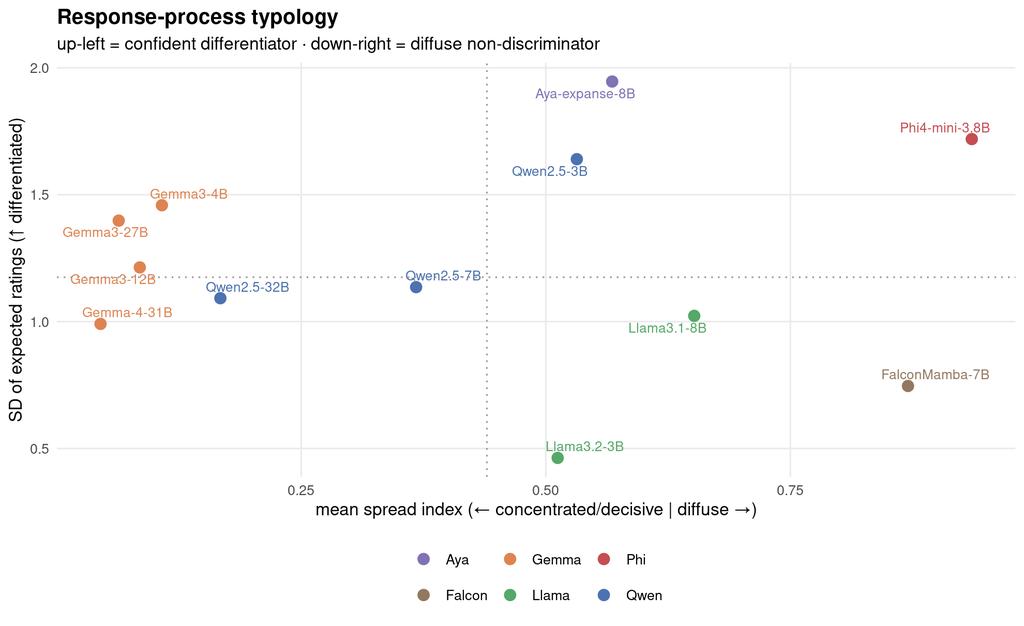

```r
typ <- summ %>% left_join(sp_summ, by = "display")
ggplot(typ, aes(mean_spread, ev_sd, colour = family, label = display)) +
  geom_point(size = 3) +
  ggrepel::geom_text_repel(size = 3, max.overlaps = 20, seed = 2) +
  scale_colour_manual(values = FAM_PAL, name = NULL) +
  geom_vline(xintercept = median(typ$mean_spread), linetype = 3, colour = "grey60") +
  geom_hline(yintercept = median(typ$ev_sd), linetype = 3, colour = "grey60") +
  labs(title = "Response-process typology",
       subtitle = "up-left = confident differentiator · down-right = diffuse non-discriminator",
       x = "mean spread index (← concentrated/decisive | diffuse →)",
       y = "SD of expected ratings (↑ differentiated)") +
  theme_judge()
```

This typology is the load-bearing setup for reliability — but with a twist that Report III makes precise and that is easy to get wrong: a **diffuse non-discriminator carries little *differentiated* information** (its between-pair variance is small), yet it still **agrees with the consensus** and does not inject noise (its judgments are a smooth, prevalence-tracking, compressed image of the crowd’s). So the flat raters are *low-information*, not *low-quality*; the raters that actually pull away from the consensus turn out to be the high-variance *idiosyncratic* models, not the flat ones. Weighting/trimming therefore buys much less than the typology first suggests (Report III §3, Report V).

## 5. Marginal structure: base rates (prevalence) and anchor generosity

Because the diagonal (self-pairs) was not collected, each rater’s matrix has two informative margins:

- **column mean** = how strongly adjective *j* is ascribed *given any anchor* — a **base rate / prevalence** (“Awake”, “Normal” are ascribed to almost anyone).
- **row mean** = how generously anchor *i* ascribes *other* traits — anchor-level acquiescence.

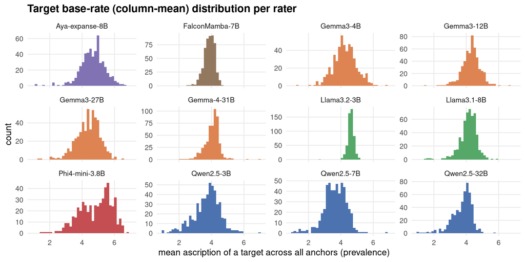

```r
mm <- marg %>% mutate(display = factor(DISPLAY[model], levels = disp_ord))
ggplot(mm, aes(col_mean, fill = FAMILY[model])) +
  geom_histogram(bins = 40) + facet_wrap(~display, ncol = 4, scales = "free_y") +
  scale_fill_manual(values = FAM_PAL, guide = "none") +
  labs(title = "Target base-rate (column-mean) distribution per rater",
       x = "mean ascription of a target across all anchors (prevalence)", y = "count") +
  theme_judge()
```

```r
cohort_prev <- mm %>% group_by(adjective) %>% summarise(prev = mean(col_mean)) %>%
  arrange(desc(prev))
knitr::kable(
  bind_cols(
    cohort_prev %>% slice_head(n = 12) %>% transmute(`Most universally ascribed` = adjective, `μ` = round(prev,2)),
    cohort_prev %>% slice_tail(n = 12) %>% arrange(prev) %>% transmute(`Least ascribed` = adjective, ` μ` = round(prev,2))
  ), caption = "Cohort-mean target base rates (prevalence marginals).")
```

Cohort-mean target base rates (prevalence marginals).

| Most universally ascribed | μ | Least ascribed | μ |
| --- | --- | --- | --- |
| thinking | 6.05 | retarded | 1.72 |
| awake | 5.74 | blind | 1.94 |
| lovable | 5.28 | tiny | 2.28 |
| valuable | 5.25 | senile | 2.49 |
| complex | 5.22 | artificial | 2.60 |
| emotional | 5.18 | dumb | 2.60 |
| curious | 5.10 | stupid | 2.63 |
| unique | 5.10 | insane | 2.74 |
| persistent | 5.06 | short | 2.80 |
| employed | 5.01 | handicapped | 2.83 |
| decent | 5.01 | disgusting | 2.84 |
| unforgettable | 5.00 | evil | 2.88 |

The prevalence marginal is large and structured — and it is precisely what a marginal-free human *correlation* matrix does not contain, which is why the reliability and validity reports **double-center** (strip additive row/column marginals) before treating `B` as a similarity. It is also the primary axis of the asymmetry (Report II).

## 6. The full raw distributions: what the two moments actually hide

Sections 1–5 read each judgment through its two moments (`B`, `Hent`). We now hold the **full 523×523×7 rating distributions** for all 12 cohort raters, so we can replace the proxy with ground truth over the *entire* pair space — honest category usage, floor and ceiling mass, and a distribution-shape census — and settle, at cohort scale, what the two moments summarize well and what they miss.

This **corrects an earlier verdict** — but not in the way the internal handoff note anticipated, and the difference is itself the finding. A prior version of this section used a 35-adjective *facet-medoid* sample and concluded the `(EV, entropy)` proxy was “faithful for 10/12 models.” The natural hypothesis was that medoids — facet *exemplars*, i.e. central prototypical cases — under-represent the diffuse judgments in the messy middle of the 523² space, so the full set would look far more spread. **The data only partly bears that out** (§6.1), and the real error turns out to be one of *metric*, not *sample* (§6.3).

```r
shp  <- read_csv_("full_shape.csv") %>% as_tibble() %>%
  mutate(display = factor(DISPLAY[model], levels = disp_ord))
cm   <- read_csv_("full_catmass.csv") %>% as_tibble() %>%
  mutate(display = factor(display, levels = disp_ord), cat = factor(cat))
```

### 6.1 The medoid sample was a *reasonable* proxy for off-mode mass

Recomputing rgb’s **off-mode-mass** metric (fraction of off-diagonal cells that place ≥ 0.25 probability ≥ 2 categories away from the modal rating) on the 35-medoid sample vs the full 523² set:

```r
offmode_frac <- function(P) {           # P: matrix rows = 7-cat pmfs
  m <- max.col(P, ties.method = "first")
  far <- abs(col(P) - m) >= 2
  mean(rowSums(P * far) >= 0.25)
}
md <- fread_gz("medoids_dists.csv.gz"); pcols <- paste0("p", 1:7)
md_off <- md[model %in% MODELS, .(medoid = offmode_frac(as.matrix(.SD))),
             by = model, .SDcols = pcols]
comp <- shp %>% transmute(model, full = offmode_frac) %>%
  left_join(md_off, by = "model") %>%
  transmute(Model = DISPLAY[model],
            `Off-mode % (35-medoid)` = round(100*medoid,1),
            `Off-mode % (full 523²)` = round(100*full,1),
            `Δ` = round(100*(full-medoid),1)) %>%
  arrange(desc(`Off-mode % (full 523²)`))
knitr::kable(comp, caption = "rgb's off-mode-mass metric, medoid sample vs full 523². The medoids track it well; the drift is a few points (the Llamas roughly double off a low base).")
```

rgb’s off-mode-mass metric, medoid sample vs full 523². The medoids track it well; the drift is a few points (the Llamas roughly double off a low base).

| Model | Off-mode % (35-medoid) | Off-mode % (full 523²) | Δ |
| --- | --- | --- | --- |
| FalconMamba-7B | 78.8 | 78.3 | -0.5 |
| Phi4-mini-3.8B | 50.5 | 56.1 | 5.6 |
| Aya-expanse-8B | 26.6 | 26.2 | -0.4 |
| Llama3.1-8B | 4.8 | 10.4 | 5.6 |
| Qwen2.5-3B | 6.7 | 7.6 | 0.8 |
| Llama3.2-3B | 2.1 | 7.0 | 4.9 |
| Qwen2.5-7B | 3.0 | 4.4 | 1.4 |
| Gemma3-4B | 1.1 | 1.7 | 0.6 |
| Qwen2.5-32B | 0.7 | 1.0 | 0.4 |
| Gemma-4-31B | 0.1 | 0.3 | 0.2 |
| Gemma3-12B | 0.0 | 0.1 | 0.1 |
| Gemma3-27B | 0.0 | 0.1 | 0.1 |

### 6.2 True category usage (the honest version of §1), cohort-wide

Actual mean probability mass per rating category over all 273,006 off-diagonal judgments — no rounding, no proxy:

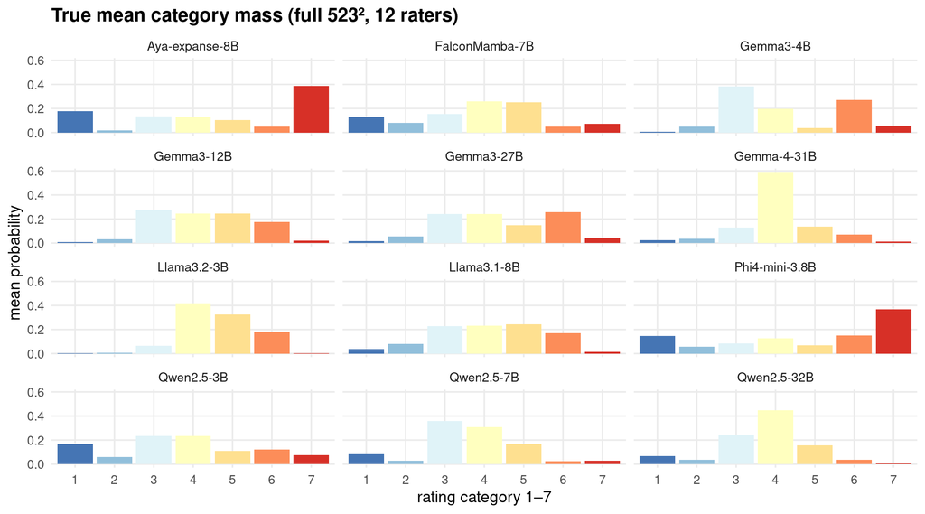

```r
ggplot(cm, aes(cat, mean_mass, fill = cat)) +
  geom_col() + facet_wrap(~display, ncol = 3) +
  scale_fill_brewer(palette = "RdYlBu", direction = -1, guide = "none") +
  labs(title = "True mean category mass (full 523², 12 raters)",
       x = "rating category 1–7", y = "mean probability") + theme_judge()
```

The *location* story of §1 holds (Qwen is floor-leaning, Gemma central-to-high, Llama3.2 hugs 4–5), but the honest picture also shows how much end-mass `Aya` and `Phi4` carry (mass on category 1 ≈ 0.18 / 0.15; on category 7 ≈ 0.39 / 0.37) — the raw signature of diffuse, often U-shaped judgments that no expected rating can convey.

### 6.3 Two different questions: *off-mode mass* vs *genuine bimodality*

“Diffuse” and “bimodal” are not the same claim, and the full data lets us separate them — which resolves what the off-mode metric can and can’t say:

- **Off-mode mass** (rgb’s metric, §6.1): how much probability sits ≥ 2 categories from the mode. High = the EV is a poor summary, but the distribution could be *broad-unimodal*.
- **Prominence bimodality** (`shape_class`, requiring a real valley < 0.6× the smaller of two peaks ≥ 0.15): a genuine two-mode “no OR yes” **semantic** mixture, distinguished from a **digit-notch** (a dip at a dispreferred digit 2/6 — a rating-channel artifact, echoing the Llama-2 category-2 suppression in the soft-evidence track).

```r
knitr::kable(
  shp %>% arrange(desc(semantic)) %>%
    transmute(Model = DISPLAY[model],
              `Off-mode %` = round(100*offmode_frac,1),
              `unimodal %` = round(100*unimodal,1),
              `semantic %` = round(100*semantic,1),
              `digit-notch %` = round(100*`digit-notch`,1),
              `adjacent %` = round(100*adjacent,1)),
  caption = "Off-mode mass vs a strict shape census over all 523². High off-mode need NOT mean bimodal.")
```

Off-mode mass vs a strict shape census over all 523². High off-mode need NOT mean bimodal.

| Model | Off-mode % | unimodal % | semantic % | digit-notch % | adjacent % |
| --- | --- | --- | --- | --- | --- |
| Aya-expanse-8B | 26.2 | 77.2 | 14.7 | 8.1 | 0.0 |
| Phi4-mini-3.8B | 56.1 | 93.3 | 5.6 | 0.1 | 0.9 |
| FalconMamba-7B | 78.3 | 90.3 | 3.4 | 6.3 | 0.0 |
| Qwen2.5-3B | 7.6 | 98.0 | 0.3 | 1.4 | 0.3 |
| Gemma-4-31B | 0.3 | 99.6 | 0.3 | 0.1 | 0.0 |
| Qwen2.5-7B | 4.4 | 95.3 | 0.3 | 4.4 | 0.0 |
| Llama3.2-3B | 7.0 | 98.8 | 0.2 | 0.0 | 1.0 |
| Qwen2.5-32B | 1.0 | 98.7 | 0.2 | 1.1 | 0.0 |
| Gemma3-4B | 1.7 | 98.3 | 0.1 | 0.0 | 1.6 |
| Llama3.1-8B | 10.4 | 99.9 | 0.0 | 0.0 | 0.0 |
| Gemma3-12B | 0.1 | 99.8 | 0.0 | 0.1 | 0.0 |
| Gemma3-27B | 0.1 | 99.9 | 0.0 | 0.0 | 0.0 |

The census sharpens §6.1 into the real finding — **three different ways to be “off-mode,” only one of them genuine bimodality:**

1. **`FalconMamba` has the *most* off-mode mass (78%) yet is *not* bimodal** — **90% unimodal**, with the off-mode share split between a small `digit-notch` component (6.3% — it under-uses digits 2 and 6 as the mode) and a broad, near-uniform spread (its mean entropy is 1.66 nats, ~85% of the `log(7)` ceiling). This is the flat rater of §§1,3 seen from the distribution side: *diffuse with a digit prior*, not a two-mode judgment. It is the sharpest example of why the off-mode flag must not be read as bimodality.
2. **`Phi4` is diffuse but *not* strongly bimodal.** Despite 56% off-mode mass it is **93% unimodal** — its judgments are *broad, flat-topped* (rgb’s “commit-vs-hedge” modes), not clean two-mode mixtures. Its EV genuinely mis-summarizes it, but the shape is spread, not split.
3. **`Aya` is the one genuinely bimodal rater** — **15% semantic** mixtures (empty-middle “almost certainly no, but sometimes yes” distributions), on top of its 26% off-mode mass. This is the case the two moments materially misread as a mid/high mean.
4. **The Gemma family (incl. the ultra-sharp `Gemma-4-31B`), `Qwen2.5-32B` and `Llama3.1-8B` are ≥ 98% unimodal** — for them EV + entropy lose essentially nothing, off-mode mass and all.
5. **Digit-2/6 suppression is real but minor**, running through `FalconMamba` (6.3%), the Qwen family (`Qwen2.5-7B` 4.4% digit-notch) and `Aya` (8%) — a rating-channel artifact to keep in mind, not substantive structure.

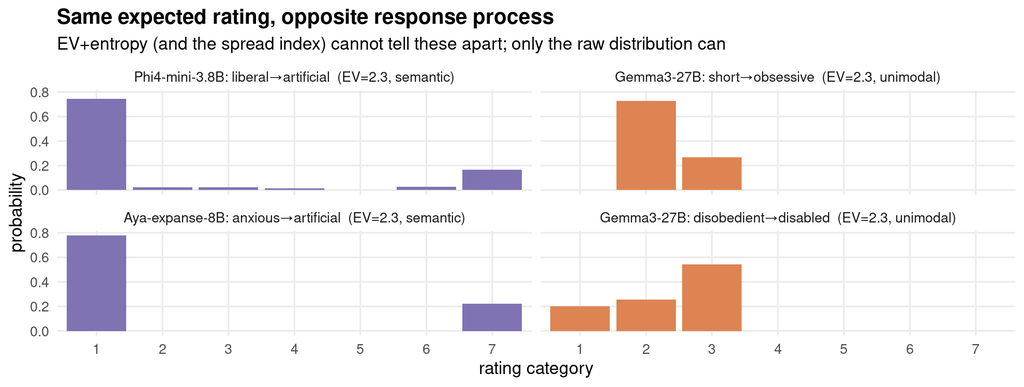

```r
ex <- read_csv_("full_examples.csv") %>% as_tibble()
exl <- ex %>%
  mutate(who = sprintf("%s: %s→%s  (EV=%.1f, %s)", display, adj_i, adj_j, ev, shape)) %>%
  select(who, shape, p1:p7) %>%
  pivot_longer(p1:p7, names_to = "cat", values_to = "p") %>%
  mutate(cat = as.integer(sub("p", "", cat)),
         who = factor(who, levels = unique(who)))
ggplot(exl, aes(factor(cat), p, fill = shape)) +
  geom_col(show.legend = FALSE) + facet_wrap(~who, ncol = 2) +
  scale_fill_manual(values = c(semantic = "#8172B3", unimodal = "#DD8452")) +
  labs(title = "Same expected rating, opposite response process",
       subtitle = "EV+entropy (and the spread index) cannot tell these apart; only the raw distribution can",
       x = "rating category", y = "probability") + theme_judge()
```

Each `Phi4`/`Aya` semantic mixture is paired with a matched-EV *unimodal* judgment from the sharp `Gemma3-27B`: identical expected rating, opposite underlying process — the exact failure mode the two-moment summary cannot see.

### 6.4 Verdict — and what it enables

The full distributions **correct the medoid-era conclusion**: the `(EV, entropy)` summary is adequate for **9 of the 12 raters** (the Gemmas, both Llamas, all three Qwens) but **not for `FalconMamba`, `Phi4` or `Aya`** — and, tellingly, it fails on all three *differently*: `FalconMamba` is diffuse-with-a-digit-prior, `Phi4` broad-unimodal, `Aya` genuinely bimodal. The spread index of §1B *did* flag all three as diffuse — it was doing its job — but a two-moment index **cannot tell those three shapes apart**, and the distinction matters for what a judgment *means*. The earlier verdict erred not because the 35-medoid sample was unrepresentative (§6.1 shows it tracked off-mode mass well) but because it certified faithfulness off *strict bimodality* alone — and `FalconMamba`/`Phi4`, ~90% unimodal yet 78%/56% off-mode, slip exactly through that gap. The lesson is methodological as much as empirical: pick the diffuseness metric that matches the question.

Two implications:

- **The under-sold flat rater.** `FalconMamba`’s graded, near-uniform mass is precisely what a mean+entropy summary throws away — yet rgb reports its *distributional* readout carries the cohort’s **strongest** correspondence to the human 525-PDA structure (EV r ≈ 0.73). The model the EV-only storage under-sold most is the one whose full distribution matters most — a direct argument for keeping the raw 7-way data.
- **The full 7-way distributions open a soft-evidence treatment** (bridging ecb’s earlier soft-evidence IRT work): distributional similarity (e.g. earth-mover distance between two judgment distributions) as an alternative to EV-cosine, and genuine confidence weighting from real distributions rather than an entropy proxy — most valuable exactly for the three raters (`FalconMamba`, `Aya`, `Phi4`) the moments fail on.

## 7. Reading the raw distributions *as response processes*

§6 used the full distributions to *audit* the two-moment summary. But the distributions carry response-process information the moments cannot even pose a question about: at a *fixed* expected rating, **how** does a model arrive there — does it slide a graded peak, split its mass, sit on a fixed digit habit, or flip a coin? This section reads the raw `(523×523×7)` tensors on their own terms. (Products from `dist_processes.py`.)

### 7.1 The response-process signature: same expected rating, different process

Fix the expected rating and look at the *shape*. Below, for each rater, is the mean 7-category distribution of its judgments as a function of their expected rating (columns = EV bins, rows = rating category, brightness = mean probability). A purely **graded** responder would trace a thin bright band along the diagonal (peak follows the EV); anything off the diagonal is a response process the EV hides.

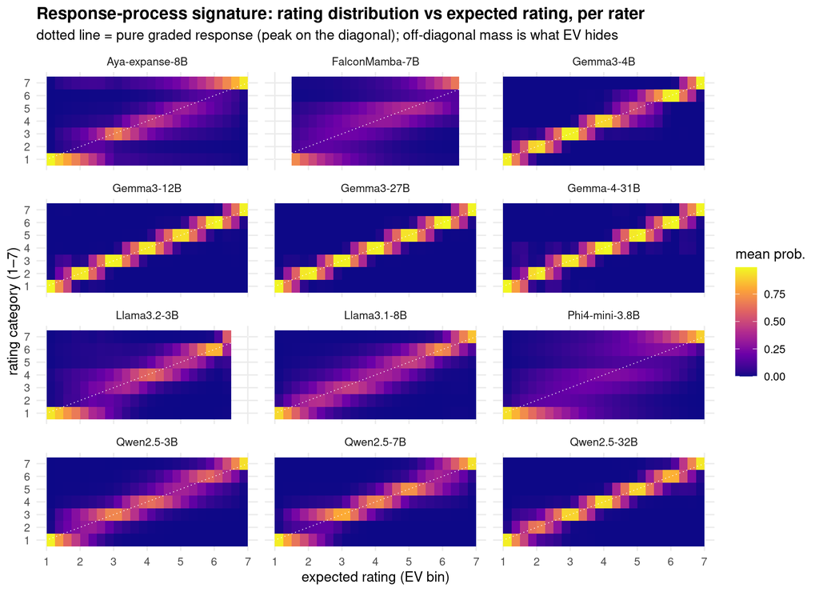

```r
sig <- read_csv_("proc_signature.csv") %>% as_tibble() %>%
  mutate(display = factor(display, levels = disp_ord))
ggplot(sig, aes(ev_bin, cat, fill = mean_mass)) +
  geom_tile() +
  geom_abline(slope = 1, intercept = 0, colour = "white", linetype = 3, linewidth = 0.3) +
  facet_wrap(~display, ncol = 3) +
  scale_fill_viridis_c(name = "mean prob.", option = "C") +
  scale_y_continuous(breaks = 1:7) +
  scale_x_continuous(breaks = 1:7, limits = c(1, 7)) +
  labs(title = "Response-process signature: rating distribution vs expected rating, per rater",
       subtitle = "dotted line = pure graded response (peak on the diagonal); off-diagonal mass is what EV hides",
       x = "expected rating (EV bin)", y = "rating category (1–7)") +
  theme_judge() + theme(legend.position = "right")
```

- **Graded slide** — the **Gemma family** (esp. `Gemma3-27B`/`Gemma-4-31B`) hugs the diagonal tightly: the distribution is a single sharp peak that tracks the expected rating almost perfectly. At EV ≈ 4 they put ~0.98 mass on category 4. This is the ideal graded response.
- **Endpoint fork** — `Aya` keeps visible mass at categories 1 **and** 7 across the *whole* EV range: at a mid-scale expected rating it is not sitting at 4, it is splitting between “no” and “yes”. The diagonal is there but a persistent two-band fork rides on top of it.
- **Fixed digit habit** — `FalconMamba` shows near-*horizontal* bands at categories 1/3/4/5 that barely move with EV: the shape is a stock digit prior, not a response to the pair (§7.2 makes this precise). `Llama3.2-3B` is the compact version — a fixed blob at 4–5.
- **Broad diffuse** — `Phi4-mini` traces the diagonal but *fat*, with a persistent secondary shoulder around 6: it commits softly and hedges wide.

### 7.2 A rater’s rating variability, decomposed: content vs hedge

The signature suggests a sharper, information-theoretic question. A rater’s *total* rating variability is `H(marginal)` — the entropy of its category usage pooled over all pairs. That splits **exactly** into two response-process pieces:

$$H(\text{marginal}) \;=\; \underbrace{I(\text{pair};\text{rating})}_{\text{content: how much the pair drives the rating}} \;+\; \underbrace{\overline{H(\text{rating}\mid\text{pair})}}_{\text{hedge: mean within-judgment entropy}}$$

The first term is the **mutual information** the adjective pair carries about the rating — the part of a rater’s output that is *about the question*. The second is its mean per-judgment entropy — fixed hedging that is the same whatever the pair. `mean Hent` (the decisiveness of §3) is only the *second* term; the raw distributions give us the first.

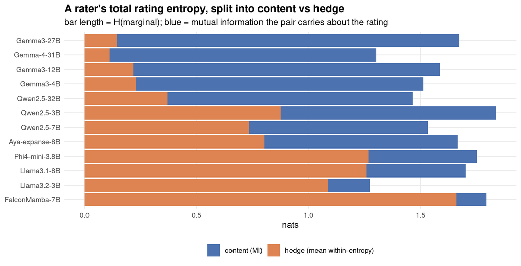

```r
con <- read_csv_("proc_content.csv") %>% as_tibble() %>%
  mutate(display = factor(display, levels = disp_ord))
cl <- con %>%
  transmute(display, content_frac,
            `content (MI)` = MI_nats, `hedge (mean within-entropy)` = mean_within_entropy) %>%
  pivot_longer(c(`content (MI)`, `hedge (mean within-entropy)`),
               names_to = "component", values_to = "nats") %>%
  mutate(display = factor(display, levels = con$display[order(con$content_frac)]))
ggplot(cl, aes(nats, display, fill = component)) +
  geom_col() +
  scale_fill_manual(values = c("content (MI)" = "#4C72B0",
                               "hedge (mean within-entropy)" = "#DD8452"), name = NULL) +
  labs(title = "A rater's total rating entropy, split into content vs hedge",
       subtitle = "bar length = H(marginal); blue = mutual information the pair carries about the rating",
       x = "nats", y = NULL) + theme_judge()
```

```r
knitr::kable(
  con %>% arrange(desc(content_frac)) %>%
    transmute(Model = display, `H(marginal)` = round(H_marginal, 2),
              `MI (content)` = round(MI_nats, 2), `mean Hent (hedge)` = round(mean_within_entropy, 2),
              `content %` = round(100 * content_frac, 1)),
  caption = "The rating-variability budget. 'content %' = fraction of a rater's rating entropy that is about the pair.")
```

The rating-variability budget. ‘content %’ = fraction of a rater’s rating entropy that is about the pair.

| Model | H(marginal) | MI (content) | mean Hent (hedge) | content % |
| --- | --- | --- | --- | --- |
| Gemma3-27B | 1.67 | 1.53 | 0.14 | 91.5 |
| Gemma-4-31B | 1.30 | 1.19 | 0.11 | 91.5 |
| Gemma3-12B | 1.59 | 1.37 | 0.22 | 86.3 |
| Gemma3-4B | 1.51 | 1.28 | 0.23 | 84.8 |
| Qwen2.5-32B | 1.46 | 1.09 | 0.37 | 74.7 |
| Qwen2.5-3B | 1.84 | 0.96 | 0.88 | 52.3 |
| Qwen2.5-7B | 1.53 | 0.80 | 0.74 | 52.1 |
| Aya-expanse-8B | 1.67 | 0.87 | 0.80 | 51.9 |
| Phi4-mini-3.8B | 1.75 | 0.48 | 1.27 | 27.6 |
| Llama3.1-8B | 1.70 | 0.44 | 1.26 | 26.0 |
| Llama3.2-3B | 1.27 | 0.19 | 1.09 | 14.8 |
| FalconMamba-7B | 1.79 | 0.13 | 1.66 | 7.5 |

So the low-information raters of Report III are low-information *distributionally* — not because they use a narrow slice of the scale (FalconMamba doesn’t), but because their distributions barely **depend** on the pair. This is the mutual-information version of the “SD of B” axis, and it is the quantity a soft-evidence model should actually weight by (a high-entropy but low-content judgment deserves *little* weight — exactly what an inverse-entropy weight gets wrong for `FalconMamba`).

### 7.3 What the *second* mode means: three mechanisms behind “off-mode” mass

When a distribution *is* multi-modal, the two moments (and even the off-mode-mass flag of §6) can’t say what the second mode is *for*. Censusing the (lower, higher) mode pair of every genuinely bi-modal cell separates three completely different response processes:

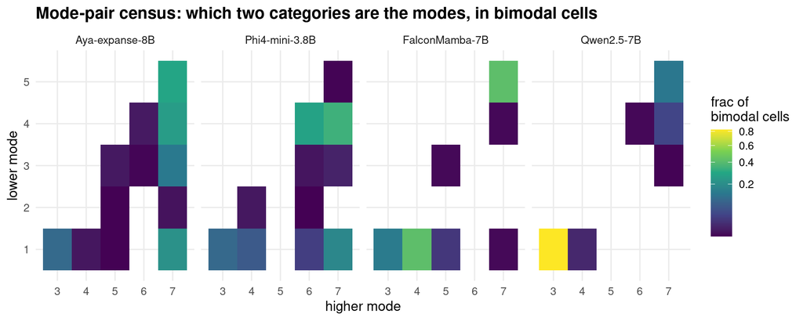

```r
mp <- read_csv_("proc_modepairs.csv") %>% as_tibble()
key <- c("Aya-expanse-8B", "Phi4-mini-3.8B", "FalconMamba-7B", "Qwen2.5-7B")
mpk <- mp %>% filter(display %in% key) %>%
  mutate(display = factor(display, levels = key))
ggplot(mpk, aes(hi, lo, fill = frac)) +
  geom_tile() + facet_wrap(~display, nrow = 1) +
  scale_fill_viridis_c(name = "frac of\nbimodal cells", option = "D", trans = "sqrt") +
  scale_x_continuous(breaks = 1:7) + scale_y_continuous(breaks = 1:7) +
  labs(title = "Mode-pair census: which two categories are the modes, in bimodal cells",
       x = "higher mode", y = "lower mode") + theme_judge() + theme(legend.position = "right")
```

- **No-OR-yes (semantic)** — the `(1, 7)` corner: a genuine “almost certainly not / sometimes yes” mixture. Present but a *minority* even where it is most common (`Aya` ~21% of its bimodal cells; `Phi4` ~18%).
- **Commit-vs-hedge** — `Phi4`’s signature: its dominant mode pairs are `(4, 7)` (34%) and `(4, 6)` (28%) — a *hedge* mode at the mid-scale and a *commit* mode at the top, exactly rgb’s reading. This is not “no vs yes”; it is “shrug vs endorse”, and it rides on top of a broadly unimodal shape (which is why `Phi4` is 93% unimodal yet 56% off-mode).
- **Digit-notch artifact** — `Qwen2.5-7B` is **82%** `(1, 3)`: a mode at 1 and a mode at 3 with the dip at the dispreferred digit *2*. `FalconMamba`’s pairs are `(1, 4)` and `(5, 7)` (42% each) — lumps between its preferred digits 1/3/4/5, skipping 2 and 6. These “modes” are a **tokenizer prior**, not a judgment — the distributional echo of the Llama-2 category-2 suppression from the soft-evidence track.

So a single “bimodality” flag conflates a semantic mixture, a commit/hedge split, and a rating-channel artifact. Only the raw distribution — specifically *where* the modes sit — tells them apart.

### 7.4 Coin-flips on ill-posed pairs: where EV is *most* misleading

The starkest response process is the balanced `(1, 7)` **coin-flip**: half the mass on “very unlikely”, half on “very likely”, nothing between. Its expected rating is ≈ 4 — dead neutral — but the process is the opposite of a neutral judgment. These cells are rare (`Aya` ~3% of judgments; others < 1%) and, tellingly, they **cluster on category-orthogonal targets**:

```r
ex <- read_csv_("proc_endpoint_examples.csv") %>% as_tibble()
knitr::kable(
  ex %>% filter(display %in% c("Aya-expanse-8B", "Phi4-mini-3.8B", "Qwen2.5-3B")) %>%
    group_by(display) %>% slice_head(n = 3) %>% ungroup() %>%
    transmute(Rater = display, Pair = paste0(adj_i, " → ", adj_j),
              EV = round(ev, 1), `p(1)` = round(p1, 2), `p(7)` = round(p7, 2)),
  caption = "Balanced 1-vs-7 coin-flips. EV reads ‘neutral’; the process is maximal binary uncertainty.")
```

Balanced 1-vs-7 coin-flips. EV reads ‘neutral’; the process is maximal binary uncertainty.

| Rater | Pair | EV | p(1) | p(7) |
| --- | --- | --- | --- | --- |
| Aya-expanse-8B | sentimental → artificial | 4.0 | 0.50 | 0.50 |
| Aya-expanse-8B | determined → artificial | 4.0 | 0.50 | 0.50 |
| Aya-expanse-8B | truthful → good-for-nothing | 4.0 | 0.50 | 0.50 |
| Phi4-mini-3.8B | intelligent → guilty | 4.1 | 0.43 | 0.43 |
| Phi4-mini-3.8B | religious → guilty | 4.1 | 0.43 | 0.43 |
| Phi4-mini-3.8B | superstitious → unattractive | 4.0 | 0.42 | 0.42 |
| Qwen2.5-3B | outstanding → good-for-nothing | 4.0 | 0.50 | 0.50 |
| Qwen2.5-3B | narrow-minded → artificial | 4.0 | 0.49 | 0.49 |
| Qwen2.5-3B | thankful → evil | 4.0 | 0.49 | 0.49 |

### 7.5 What this adds

Read as response processes, the raw distributions turn “how uncertain is this rater” into **“uncertain *how*”**: content vs hedge (§7.2), graded-slide vs endpoint-fork vs fixed-digit (§7.1), semantic mixture vs commit/hedge vs digit artifact (§7.3), and coin-flip-on-ill-posed (§7.4). None of these is recoverable from `B` and `Hent`. Two have immediate measurement payoff: (a) **content share** `I(pair;rating)/H(marginal)` is the right per-rater information weight (and correctly demotes `FalconMamba`, which an entropy weight would over-trust), and (b) the mode-pair mechanism tells a soft-evidence model *which* off-mode mass is signal (semantic) versus nuisance (digit artifact) — a cleaner footing than either the EV-cosine or a raw earth-mover distance.